# plot-distributions-for-HMOX1-cohorts-for-TH34 2351 S01-in-pan-disease-and-other-cohorts

hbeale

May 14, 2024

Version 2023.11.21_11.24.15 - focuses on genes found only relative to TCGA, not relative to any other cohort. Previous versions focused on outliers detected relative to TCGA and not treehouse, irrespective of whatever other cohorts they were outliers in

Version 2023.11.29_09.19.33 - focuses on all druggable genes, not only genes that were outliers vs one cohort or another

Version 2023.11.30_16.40.01 - incorporates pan disease cohorts

version 2023.12.12_14.51.20 - trying to make the output more searchable

version 2024.01.11_12.04.21 - update names of pan disease cohorts from pan_disease_same_inferred_diagnosis to Disease of the top 6 most correlated samples.

version 2024.01.16_13.17.13 - update names of pan disease cohorts from Disease of the top 6 most correlated samples to Disease of the top 6 most correlated datasets

# General reference files

```r
treehouse_druggable_genes <- read_tsv("../input_data/treehouseDruggableGenes_2020-03_25.txt")
gene_name_conversion <- read_tsv("../input_data/non_compendium_expression/EnsGeneID_Hugo_Observed_Conversions.txt")
outliers <- read_tsv("../input_data/druggable_outliers_from_treehouse_and_other_cohorts_2023_11_09-13_46_32_2023.tsv") %>%
  mutate(high_level_cohort = ifelse(str_detect(comparison_cohort, "Treehouse"),
                                    "Treehouse",
                                    comparison_cohort))
```

```r
other_genes_of_interest <- tribble(
  ~gene, ~Sample_ID, ~outlier_relative_to,
  "MAP2K1", "TH34_1350_S01", "non_outlier promoted by curation",
  "MAP2K1", "TH34_1351_S01", "non_outlier promoted by curation",
  "CDK1", "TH34_2293_S01", "non_outlier promoted by curation",
  "NOTCH3", "TH34_2293_S01", "non_outlier promoted by curation",
  "MAP2K1", "TH34_2351_S01", "non_outlier promoted by curation",
  "PSMC1", "TH34_1447_S02", "single cohort pan disease outlier",
  "PSMD4", "TH34_1447_S02", "single cohort pan disease outlier",
  "FLT4", "TH34_2666_S01",  "pan cancer and single cohort pan disease outlier",
  "MDM2", "TH34_2666_S01",  "pan cancer and single cohort pan disease outlier",
  "ERBB2", "TH34_1381_S01", "pd in contemporary analysis",
)

all_genes_of_interest <- c(treehouse_druggable_genes$gene,
                           other_genes_of_interest$gene,
                           outliers$gene) %>%
  unique()
```

# COMPARE DISTRIBUTIONS FOR OUTLIERS ACROSS COHORTS

```r
outlier_genes_detected <- unique(outliers$gene)

v11_expr <- read_tsv("../input_data/druggable_plus_TumorCompendium_v11_PolyA_hugo_log2tpm_58581genes_2020-04-09.tsv.gz") %>%
  rename(Sample_ID = TH_id) %>%
  mutate(ever_outlier_in_ckcc2 = Gene %in% outlier_genes_detected)
stanford_samples  <- read_tsv("../gather_input_data/comparison_to_non_CARE_cohorts/data/TH03_TH34_rollup.sample_list.txt",
                              col_names = "Sample_ID") %>%
  mutate(cohort = "TH03_TH34")
TCGA_samples  <- read_tsv("../gather_input_data/comparison_to_non_CARE_cohorts/data/TCGA_rollup.sample_list.txt",
                              col_names = "Sample_ID") %>%
  mutate(cohort = "TCGA")
PEDAYA_samples  <- read_tsv("../gather_input_data/comparison_to_non_CARE_cohorts/data/PEDAYA_rollup.sample_list.txt",
                              col_names = "Sample_ID") %>%
  mutate(cohort = "PEDAYA")
pd_cohorts <- read_tsv("../input_data/v11_automated_pan_disease_cohort_members_2023_12_15-16_36_37_2023.tsv") %>%
  rename(original_cohort_name = cohort,
         focus_sample_ID = TH_id,
         Sample_ID = cohort_member) %>%
  mutate(
         cohort_pd_subset = str_replace(original_cohort_name,
                              "first_degree_mcs_cohort", "pan_disease_1st_degree") %>%
           str_replace("first_and_second_degree_mcs_cohort", "pan_disease_1st_and_2nd_degree") %>%
           str_replace("diagnosed_disease_cohort", "pan_disease_same_diagnosis") %>%
           str_replace("pandisease_samples", "pan_disease_same_inferred_diagnosis"),
         cohort = paste(focus_sample_ID, cohort_pd_subset))
# dput(unique(pd_cohorts$cohort))
n_distinct(pd_cohorts$cohort)
```

```
## [1] 113
```

```r
v8_expr <- read_tsv("../input_data/v8_expr_for_ckcc2.tsv.gz") %>%
  filter(Gene %in% all_genes_of_interest) %>%
  mutate(ever_outlier_in_ckcc2 = Gene %in% outlier_genes_detected)
v10_expr <- read_tsv("../input_data/v10_expr_for_ckcc2.tsv.gz") %>%
  filter(Gene %in% all_genes_of_interest) %>%
  mutate(ever_outlier_in_ckcc2 = Gene %in% outlier_genes_detected)
expr <- bind_rows(
  v10_expr,
  v8_expr,
  v11_expr) %>%
  distinct()

# pan_cancer_samples <- expr %>%
#   select(Sample_ID) %>%
#   distinct() %>%
#   mutate(cohort = "Treehouse_pc")

pan_cancer_samples <- v11_expr %>%
  select(Sample_ID) %>%
  distinct() %>%
  mutate(cohort = "Treehouse_pc")



samples_in_cohorts <- bind_rows(
  stanford_samples,
  TCGA_samples,
  PEDAYA_samples,
  pan_cancer_samples,
  pd_cohorts %>%
    select(cohort, Sample_ID))
```

# expression in samples not in the compendium

```r
rsem_path <- "../input_data/non_compendium_expression"

relevant_gene_name_conversion <- gene_name_conversion %>%
  filter(HugoID %in% all_genes_of_interest)

rsem_kitchen_sink_data <- tibble(file_name = list.files(
  path = rsem_path,
  pattern = "_rsem_genes.results")) %>%
  rowwise() %>%
  mutate(rsem_raw = list(read_tsv(file.path(rsem_path, file_name),
                                     show_col_types = FALSE
                                     ))) %>%
  unnest(rsem_raw) %>%
  filter(gene_id %in% relevant_gene_name_conversion$EnsGeneID) %>%
  mutate(Sample_ID = str_extract(file_name, "TH[R]?[0-9]{2}_[0-9]{4}_S[0-9]{2}")) %>%
  left_join(relevant_gene_name_conversion,
            by=c("gene_id"="EnsGeneID")) %>%
    group_by(Sample_ID, HugoID) %>%
    summarize(sum_TPM = sum(TPM),
              n=n()) %>%
    mutate(log2TPM1 = log2(sum_TPM +1))
table(rsem_kitchen_sink_data$n)
```

```
##
##   1   2
## 560  10
```

```r
patient_expression_from_rsem_files <- rsem_kitchen_sink_data %>%
  select(gene = HugoID,
         log2TPM1,
         Sample_ID)


patient_expression_from_compendia <- bind_rows(outliers,
                                               other_genes_of_interest) %>%
  select(Sample_ID, gene) %>%
  distinct() %>%
  left_join(expr,
            by=c("Sample_ID", "gene"="Gene")) %>%
  na.omit() # excludes samples not in compendium

patient_expression <- bind_rows(
  patient_expression_from_rsem_files,
  patient_expression_from_compendia)  %>%
  mutate(ever_outlier_in_ckcc2 = gene %in% outlier_genes_detected) %>%
  mutate(log2TPM1 = round(log2TPM1,6)) %>%
  distinct()

# patient_expression %>% select(gene, Sample_ID) %>%
#   duplicated() %>% which
#
# patient_expression[c(655, 656, 682),] %>% select(gene, Sample_ID) %>%
#   left_join(patient_expression) %>%
#   distinct() %>%
#   select(-ever_outlier_in_ckcc2) %>%
#   distinct() %>%
#   mutate(log2TPM1 = round(log2TPM1,6)) %>%
#   distinct()

length(outlier_genes_detected)
```

```
## [1] 56
```

# Determine where to find additional expression data

```r
# v8 <- read_tsv("https://xena.treehouse.gi.ucsc.edu/download/TreehousePEDv8_clinical_metadata.2018-07-25.tsv")
# v9 <- read_tsv("https://xena.treehouse.gi.ucsc.edu/download/TreehousePEDv9_clinical_metadata.2019-03-15.tsv")
# v10 <- read_tsv("https://xena.treehouse.gi.ucsc.edu/download/clinical_TumorCompendium_v10_PolyA_2020-01-28.ts
# v")
#
# samples_in_cohorts %>%
#   filter(cohort == "TH34_1351_S01 pan_disease_1st_and_2nd_degree")
#
# samples_in_cohorts %>%
#   filter(! Sample_ID %in% expr$Sample_ID) %>%
#   select(Sample_ID) %>%
#   distinct()

# samples_in_cohorts %>%
#   filter(! Sample_ID %in% expr$Sample_ID) %>%
#   select(Sample_ID) %>%
#   distinct() %>%
#   pull(Sample_ID) %>%
#   cat(sep = " ")
#
# samples_in_cohorts %>%
#   filter(! Sample_ID %in% expr$Sample_ID) %>%
#   filter(! Sample_ID %in% v8$th_sampleid) %>%
#   filter(! Sample_ID %in% v10$th_sampleid) %>%
#   select(Sample_ID) %>%
#   distinct()

# Conclusion
# all but TH34_1456_S02 are in v8
# TH34_1456_S02 is not in v9
# TH34_1456_S02 is  in v10
# are all in v10? no. so add data from v8 and v10
```

# retrieve additiona expression data

servers were going very slowly, so i got v8 and v10 on different servers (razzmatazz and crimson)

```r
setwd("/scratch/hbeale/")
Sys.setenv("VROOM_CONNECTION_SIZE" = 131072 * 2)
library(tidyverse)
v8 <- read_tsv("https://xena.treehouse.gi.ucsc.edu/download/TreehousePEDv8_unique_hugo_log2_tpm_plus_1.2018-07-25.tsv")
v10 <- read_tsv("https://xena.treehouse.gi.ucsc.edu/download/TumorCompendium_v10_PolyA_hugo_log2tpm_58581genes_2019-07-25.tsv")

samples_with_expr_to_retrieve <- "TH03_0296_S05 THR14_0307_S01 THR14_1181_S01 THR14_1182_S01 THR14_1185_S01 THR14_1196_S01 THR14_1197_S01 THR14_1203_S01 THR14_1213_S01 THR14_1220_S01 THR14_1229_S01 THR14_1230_S01 THR14_1231_S01 THR14_1232_S01 THR14_1233_S01 THR14_1234_S01 THR14_1235_S01 THR14_1236_S01 THR33_1131_S01 THR33_1139_S01 THR14_1180_S01 THR14_1183_S01 THR14_1184_S01 THR14_1186_S01 THR14_1188_S01 THR14_1189_S01 THR14_1190_S01 THR14_1191_S01 THR14_1192_S01 THR14_1194_S01 THR14_1195_S01 THR14_1198_S01 THR14_1199_S01 THR14_1200_S01 THR14_1201_S01 THR14_1202_S01 THR14_1204_S01 THR14_1205_S01 THR14_1206_S01 THR14_1207_S01 THR14_1209_S01 THR14_1211_S01 THR14_1212_S01 THR14_1214_S01 THR14_1215_S01 THR14_1216_S01 THR14_1217_S01 THR14_1218_S01 THR14_1219_S01 THR14_1221_S01 THR14_1222_S01 THR14_1223_S01 THR14_1237_S01 THR35_1254_S01 THR14_1208_S01 THR14_1210_S01 TH34_1456_S02" %>%
  str_split(" ") %>% unlist()

v8_relevant <- v8 %>% select(Gene, any_of(samples_with_expr_to_retrieve))

v8_relevant_longer <- pivot_longer(v8_relevant,
             -Gene,
             names_to = "Sample_ID",
             values_to = "log2TPM1")

# write_tsv(v8_relevant_longer, "v8_expr_for_ckcc2.tsv.gz")

v10_relevant <- v10 %>% select(Gene, any_of(samples_with_expr_to_retrieve))

v10_relevant_longer <- pivot_longer(v10_relevant,
             -Gene,
             names_to = "Sample_ID",
             values_to = "log2TPM1")

# write_tsv(v10_relevant_longer, "v10_expr_for_ckcc2.tsv.gz")
```

# Calculate statistics for each cohort

```r
cohort_thresholds_raw <- left_join(samples_in_cohorts,
                                   expr,
                                   by=c("Sample_ID")) %>%
  #na.omit() %>% # while I'm missing expression data for some samples
  group_by(Gene, cohort) %>%
  summarize(q25 = quantile(log2TPM1, 0.25),
            median = median(log2TPM1),
            q75 = quantile(log2TPM1, 0.75),
            IQR = q75-q25,
            up_outlier_threshold = q75 + (1.5*IQR))
```

# assess changes for all genes

```r
cohort_thresholds <- cohort_thresholds_raw %>%
  pivot_longer(c(-Gene, -cohort),
               names_to = "stat") %>%
  pivot_wider(names_from = cohort, values_from = value) %>%
  mutate(frac_change_in_ped_relative_to_TCGA =
              (PEDAYA - TCGA) / TCGA,
         frac_change_in_treehouse_relative_to_TCGA =
            (Treehouse_pc - TCGA) / Treehouse_pc)
```

```r
# PSMC1 is not in cohort_thresholds because it was not druggable
#   expr %>%
#   filter(Gene == "PSMC1")


outliers_to_plot <- outliers %>%
  group_by(gene, Sample_ID) %>%
  summarize(outlier_relative_to = paste(comparison_cohort, collapse = ", "))
calculate_outlier_threshold <- function(x) {
  # x <- 1:100
  q75 <- quantile(x, 0.75)
  iqr <- q75 - quantile(x, 0.25)
  threshold <- q75 + 1.5*iqr
  return(threshold)
}
```

# Rename cohorts here

```r
update_cohort_strings <- function(x) {
  str_replace(x,
              "PEDAYA",
              "Pediatric") %>%
    str_replace("TH03_TH34",
                "Stanford")%>%
    str_replace("Treehouse_pc",
                "Treehouse pan-cancer")%>%
    str_replace("pan_disease",
                "Treehouse pan-disease,") %>%
    str_replace("1st_degree", "1st degree neighbors") %>%
    str_replace("1st_and_2nd_degree", "1st and 2nd degree neighbors") %>%
    str_replace("same_diagnosis", "same disease as focus sample") %>%
    str_replace("same_inferred_diagnosis", "diseases of top 6 most correlated datasets") %>%
    str_replace_all("_([a-z12][a-z])", " \\1")
}
```

# Function to plot distributions and patient expression

```r
plot_distributions <- function(this_gene, this_sample_id, outlier_relative_to) {
  # this_sample_id <- "TH34_2351_S01"
  # this_gene <- "HMOX1"

  print(this_gene)

  print(this_sample_id)

  possible_levels <- c("Treehouse_pc", "TCGA", "PEDAYA", "TH03_TH34",
                       paste(this_sample_id, c("pan_disease_same_diagnosis",
                                               "pan_disease_same_inferred_diagnosis",
                                               "pan_disease_1st_degree",
                                               "pan_disease_1st_and_2nd_degree"))) %>%
    update_cohort_strings

  expr_relevant_to_this_outlier_raw <-  left_join(
    samples_in_cohorts %>%
      filter(str_detect(cohort, this_sample_id) |
               cohort %in% c("PEDAYA", "TCGA", "TH03_TH34", "Treehouse_pc")),
    expr %>%
      filter(Gene == this_gene),
    by=c("Sample_ID")) %>%
    mutate(cohort = update_cohort_strings(cohort))

  expected_levels <- possible_levels[possible_levels %in% expr_relevant_to_this_outlier_raw$cohort]

  expr_relevant_to_this_outlier <- expr_relevant_to_this_outlier_raw%>%
    # na.omit() %>%  # while I'm missing expression data for some samples
    mutate(cohort =
             fct_relevel(cohort, expected_levels)) %>%
    arrange(cohort) %>%
    group_by(cohort) %>%
    mutate(cohort_with_n = paste0(cohort, " (n=", scales::label_comma()(n()), ")")) %>%
    ungroup %>%
    mutate(cohort_with_n = factor(cohort_with_n,
                                  levels = unique(cohort_with_n)))


  outlier_thresholds <- expr_relevant_to_this_outlier %>%
    group_by(cohort_with_n) %>%
    summarize(
      outlier_threshold = calculate_outlier_threshold(log2TPM1)) %>%
    ungroup() %>%
    mutate(patient_expression = patient_expression %>%
             filter(gene == this_gene,
                    Sample_ID == this_sample_id) %>%
             pull(log2TPM1),
           patient_is_outlier = patient_expression > outlier_threshold)


  p <- ggplot(expr_relevant_to_this_outlier) +
    geom_boxplot(aes(y=cohort_with_n, x=log2TPM1),
                 #fill = cohort_with_n),
                 outlier.shape = NA) +
    geom_rect(data = outlier_thresholds,
              aes(xmin = outlier_threshold,
                  xmax = Inf,
                  ymin = -Inf,
                  ymax = Inf),
              fill = "yellow",
              alpha = 0.7) +
    geom_vline(data = outlier_thresholds,
               aes(xintercept = patient_expression,
                   #lty = patient_is_outlier
               ),
               color = "red") +
    facet_col(~cohort_with_n, scales = "free_y") +
    theme_minimal() +
    xlab(paste0(this_gene," expression (log2(TPM+1))")) +
    theme(axis.text.y = element_blank(),
          axis.title.y = element_blank(),
          legend.position="none",
          panel.border = element_rect(colour = NA, fill=NA, size=1),
          strip.background = element_rect(color = "lightgrey", size = 1, fill = "lightgrey"),
          panel.grid.major.y = element_blank()) +         #remove horizontal grid line
    ggtitle(paste0(this_gene, " cohorts for ", this_sample_id, "; ", outlier_relative_to),
            "red line is patient expression (dashed if outlier); yellow area is above the outlier threshold")



  return(p)
}
```

# create HMOX1 cohorts for TH34_2351_S01 distribution figure for manuscript

```r
outlier_for_figure <- outliers_to_plot %>%
  filter(Sample_ID ==  "TH34_2351_S01",
         gene == "HMOX1")

t3 <- plot_distributions(outlier_for_figure$gene, outlier_for_figure$Sample_ID, outlier_for_figure$outlier_relative_to)
```

```
## [1] "HMOX1"
## [1] "TH34_2351_S01"
```

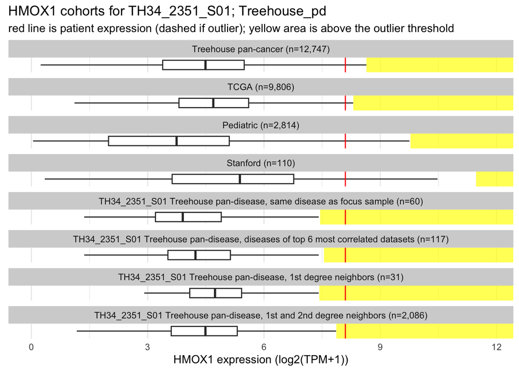

```r
t3
```

```r
plot_output_name <- paste0("../results/Expression of TH34_2351_S01 and cohorts ", format(Sys.time(), "%Y_%m_%d-%H_%M_%S_%Y"), ".png")

ggsave(filename = plot_output_name,
       bg = "white",
       plot = t3)
```

this output was saved as ../results/Expression of TH34_2351_S01 and cohorts 2024_05_14-16_58_37_2024.png